# Evaluation

Prompt Engineering

Mick McQuaid

mcq@utexas.edu

University of Texas at Austin

16 Nov 2025

# Week THIRTEEN

# First, an Agentic-AI conference

- You need to know about these things
- That said, this one had a lot of business fluff … circling back to leverage our proactive synergies for a win-win
- I want to highlight one of the presentations to warn you and to highlight one presentation and one panel that were helpful

## McKinsey presentation

- McKinsey is the world’s most prominent business strategy consulting firm
- Presenter said it’s really a tech firm in disguise and would like to consult with all of us on our AI strategies
- Presented a lot of statistics on CEO attitudes toward AI
- They evidently talk to a lot of CEOs who are mostly clueless about AI but are otherwise very smart people
- Based a lot of his presentation on the following two frames

## The NASA antecedent

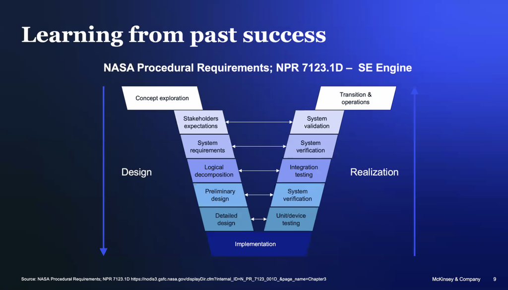

## How McKinsey adapted the NASA diagram

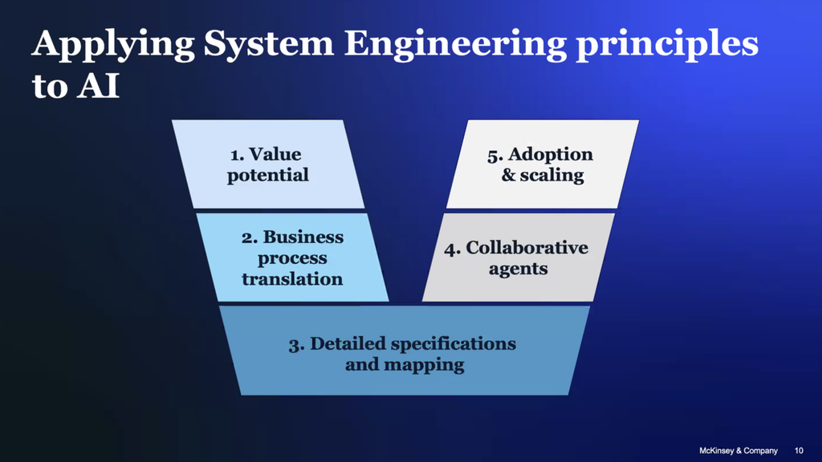

## A useful panel on vibe coding

- The expression *vibe coding* was coined by Andrei Karpathy in February
- In November, it was selected as “Word of the year” [sic] by some dictionary
- The panelists were all enthusiastic vibe coders
- I’ll upload a video to Canvas when it’s made available to me
- Main takeaway is, as always with AI, realistic expectations
- Disagreement exists over degree of coding skill needed to effectively vibe code, but these people were all experienced coders before they began
- Some agreement that, by pursuing test-driven development, vibe coding can be useful for debugging (contradicts some earlier wisdom)

## A useful presentation on data representation for AI

- Presenter was founder of Sphinx, which helps you massage data so AI can use it
- Points out that, while genAI works for text and images, it does not do well on tabular data—needs agentic tools, which Sphinx conveniently provides
- Gave an excellent example of genAI failure with the Ames dataset which you used for exercise D
- Showed some interesting graphics, displayed in the next two frames

## Data science benefits less from genAI than does software engineering

[figure not shown]

## Data in different states

[figure not shown]

# Chain of Thought prompting

- One student asked for some coverage of chain-of-thought (CoT)
- I thought it might be useful to survey a few recent papers on CoT
- First, let’s see what Xiao and Zhu (2025) says about CoT, then look at Yu et al. (2025), Li et al. (2025), Shen et al. (2025), and Zhang et al. (2025), all recent articles focused on CoT techniques

## Xiao and Zhu (2025)

- Discusses CoT as an advanced technique, although it’s pretty common, saying “Let’s think step by step”
- CoT somewhat mirrors human problem solving by decomposing problems
- CoT improves transparency reporting steps to user
- CoT increases potential scope by subdividing tasks
- CoT can be extended via tree or graph structures (active area of research)
- CoT can be extended via interaction during intermediate steps
- BUT … it may be difficult to obtain demonstrations
- BUT … requires review of all intermediate steps to prevent accumulating errors

## Yu et al. (2025)

- Proposes the first CoT framework for text-free graphs, GCoT
- Note that graphs are arrangements of nodes and links, not graphics!
- Graphs may represent relationships between people, drugs, photos, proteins, really any kind of objects that have relationships with other objects, the nodes being the objects and the links being the relationships
- An example of the differences between CoT for NLP and graphs is shown in the next frame, with the thoughts highlighted in red

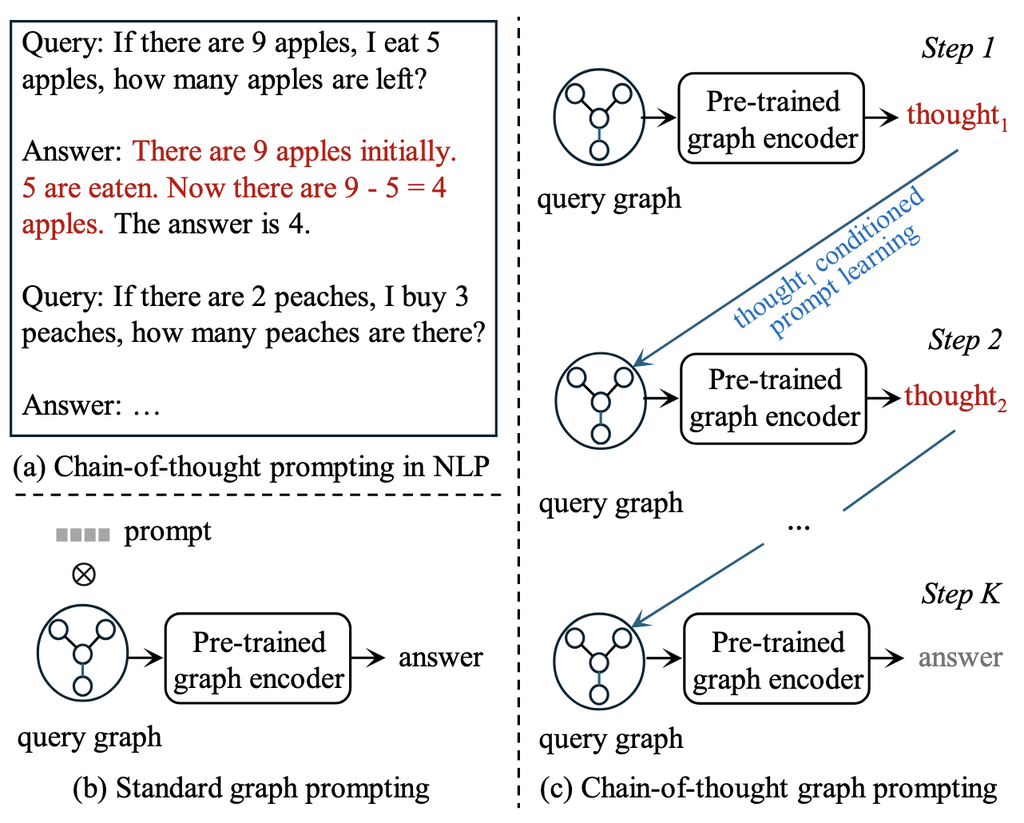

## Yu et al. (2025) process

- Developed system to represent graphs as embeddings to be used in downstream tasks, such as node classification, link prediction
- Experimented on eight well-known graph datasets
- Performed an ablation study (systematically removes layers and tests resulting variants)
- GCoT is both faster (?) and of higher quality than alternatives

## One quality measure—proximity of like classes in clustering

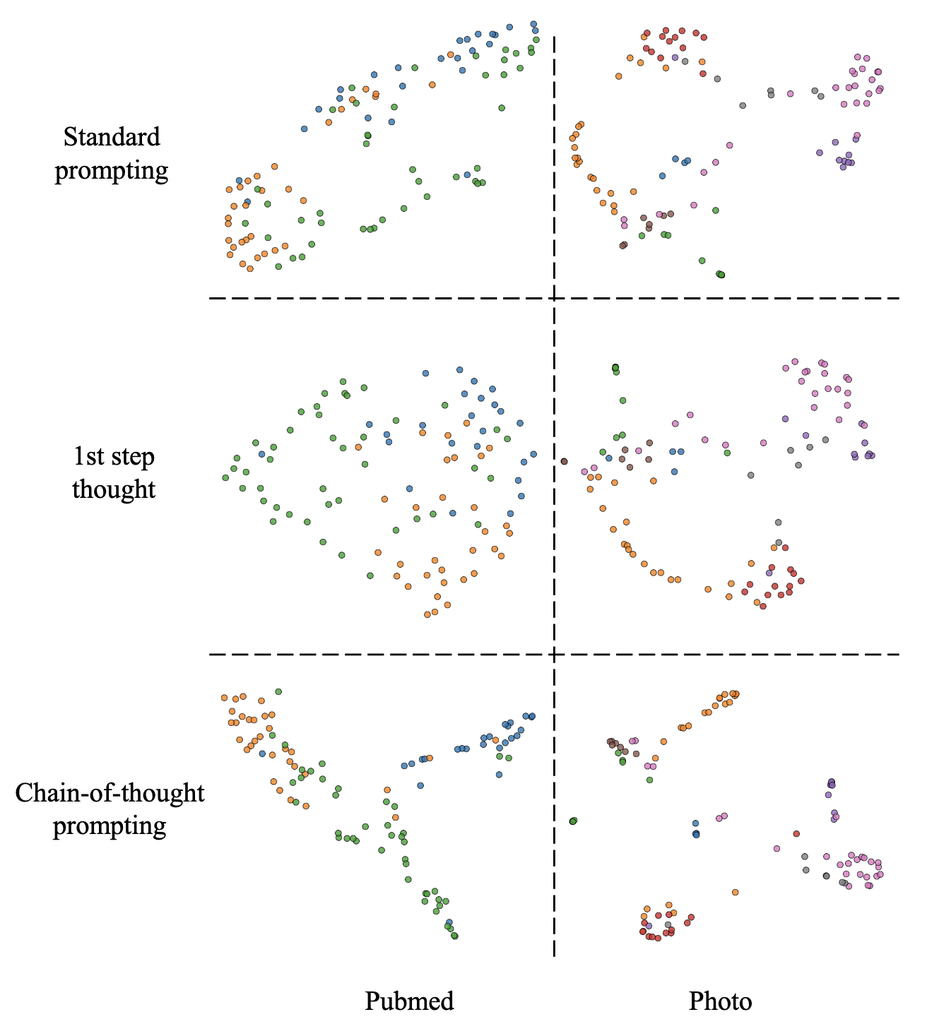

## Li et al. (2025)

- Proposes Structured Chain of Thought (SCoT) for code generation
- Code generation aims to automatically produce a computer program from a natural language description
- SCoT is based on notion that human developers practice structured programming, employing three structures: sequences, branches, and loops—and only those three
- CoT prompting only uses sequences, not branches and loops and achieves limited performance gains over generic prompting
- Yet LLMs have considerable knowledge of branches and loops, just needs to be “unlocked”
- SCoT accomplishes this “unlocking”

## SCoT process

- Two-step process, (1) Input-Output structure, and (2) Rough problem-solving process
- IO structure defines entry and exit of code, giving requirements
- Rough problem-solving process mandates that only the three constructs (sequence, branch, and loop) be used in subsequent steps

## SCoT Experience

- Uses demonstrations of structure in input
- Five LLMs: two GPT and three Deepseek Coder in various sizes
- Three benchmarks: HumanEval, MBPP, and MBCPP
- Two languages: Python and C++
- Uses unbiased Pass@*k* as evaluation metric
- Compares to zero-shot, few-shot, and CoT
- Human preference also examined (10 developers w/3–5 yrs experience)

## SCoT Example

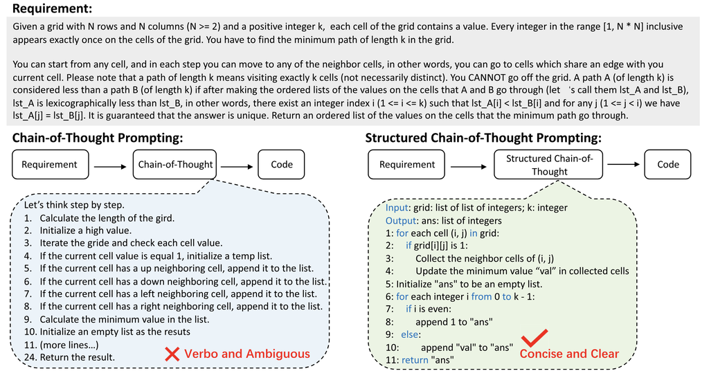

## Shen et al. (2025)

- Brief paper exploring CoT for code generation with lightweight Language models (*l*LMs)
- Assumes fewer than 10 billion parameters
- Finds nearly twenty percent improvement in Pass@1 metric for CodeT5+ 6B
- Seems motivated primarily by ease of deployment of resource-constrained *l*LMs
- Uses four CoT methods, including the SCoT of the previous paper
- Uses three benchmarks: HumanEval, OpenEval, CodeHarmony
- Uses four models: CodeT5+, Qwen2.5-Coder, Yi-Coder, Deepseek-Coder

## Zhang et al. (2025)

- Overall goal is video content comprehension
- Introduces Video-CoT, a dataset to enhance spatio-temporal understanding of CoT methods
- Note that the name Video-CoT always appears in a yellow-to-pink gradient in the paper
- Dataset contains 192,000 spatio-temporal question-answer pairs and 23,000 annotated CoT samples
- Includes a new benchmark with 750 images for assessing each task
- Conducts extensive experiments on video-language models (VLMs) and finds them wanting
- Especially concerned with event start and end times and positions of subjects

## Video-CoT overview

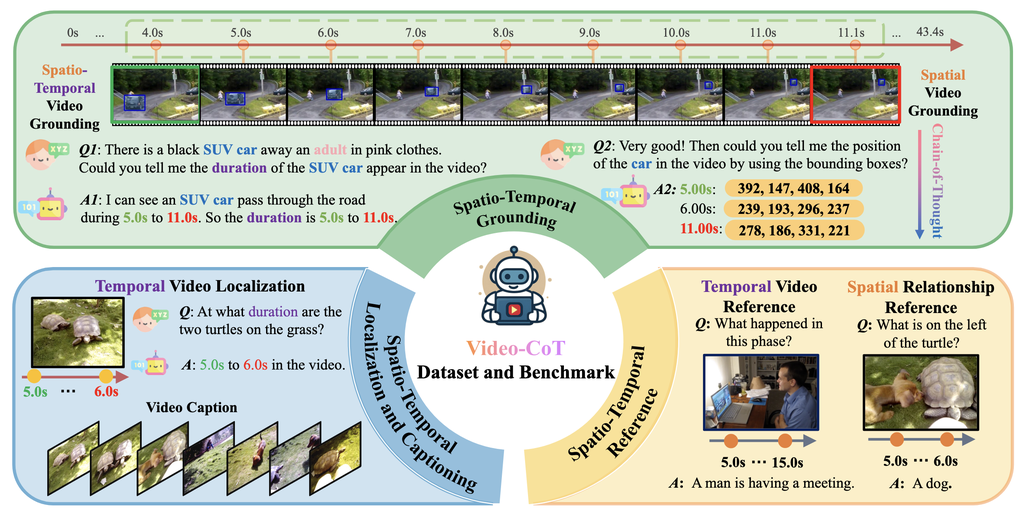

# Evaluation

- Key problem: *what* are you evaluating?
- Are you evaluating your prompt? A framework? The context? The LLM?
- Again, *what* are you evaluating?
- Typical solution to many evaluation problems: ablation
- That means subtracting elements one at a time to see the effect on output
- Risks overlooking synergies
- Here *synergies* means that the performance of two elements together is greater than the sum of their individual contributions

## Agenta.ai

- Recent improvements (last couple of weeks)
- May be less buggy than when you tried it before
- Advantage is that it balances cost, time, and performance
- Allows you to identify a scaled, weighted, linear combination of the three
- Substitutes should either help with more than one metric or be used in combinations
- Doesn’t account for alignment

## Costs

- Input tokens have different costs than output tokens
- Costs change over time and published reports are typically outdated except as to method
- There’s the hidden cost of the carbon footprint of the work
- Evaluation itself has a cost

## Time

- Time often matters as in the old saying that *Time is money*
- People are increasingly using genAI in real-time interactions, for better or worse

## Performance

- There’s always a human somewhere in the loop but automation is attractive
- Time may be considered as an aspect of performance but still a tradeoff

## Alignment

- How do you measure alignment with human objectives? Human judgment?
- How do quantify human judgment? Can you?
- How do you use or even compare the judgments of multiple humans?

## New work in evaluation

- Why explore new work in evaluation?
- People are inventing new ways and repurposing old ways to evaluate what they are doing
- You may think of a new way to evaluate your project by taking inspiration from new projects
- Following are two projects that use very different approaches to evaluation, one very quantitative and the other very qualitative

## Khatua et al. (2025)

- Khatua et al. (2025) evaluates the ability of eight LLMs to follow prompts in QA tasks
- Khatua et al. (2025) demonstrates that they often can’t and are not self-reflective
- Khatua et al. (2025) provides a framework for evaluation of the LLM itself
- Khatua et al. (2025) divides knowledge into *parametric knowledge* (coming from the training corpus) and context knowledge (coming from any of various context engineering techniques, but mainly RAG)

## Example

- Example: a new president of Liberia was recently elected, so their identity is not part of parametric knowledge
- Provided with (A) correct context, (B) masked context, (C) noisy context, or (D) absurd context
- Possible errors: (A) relying on parametric knowledge, (B) not being self-reflective, (C) relying on parametric knowledge, or (D) hallucinating

## Subramonyam et al. (2025)

- Subramonyam et al. (2025) describes a user study of prototyping applications using genAI
- Thirteen teams, each consisting of a designer, a manager, and a developer, worked on prototypes of marketing applications
- Evaluation mainly consisted of aligning results with human intentions
- Design choices are often undocumented and invisible to end users
- Overfitting to examples is common
- Discovered tendency to optimize model outputs rather than explore broader design space
- These discoveries come from qualitative research in the vein of Anselm Strauss and Juliet Corbin

# END

# References

Khatua, Aparup, Tobias Kalmbach, Prasenjit Mitra, and Sandipan Sikdar. 2025. “Evaluating LLMs’ (in)ability to Follow Prompts in QA Tasks.” In *Proceedings of the 48th International ACM SIGIR Conference on Research and Development in Information Retrieval*, 2941–45. SIGIR ’25. New York, NY, USA: Association for Computing Machinery. https://doi.org/10.1145/3726302.3730190.

Li, Jia, Ge Li, Yongmin Li, and Zhi Jin. 2025. “Structured Chain-of-Thought Prompting for Code Generation.” *ACM Trans. Softw. Eng. Methodol.* 34 (2). https://doi.org/10.1145/3690635.

Shen, Yiheng, Jing Qiu, Xiang Nan, and Hongxing Xia. 2025. “An Empirical Study of Chain-of-Thought in Lightweight Language Models.” In *Proceedings of the 2025 3rd International Conference on Educational Knowledge and Informatization*, 69–73. EKI ’25. New York, NY, USA: Association for Computing Machinery. https://doi.org/10.1145/3765325.3765338.

Subramonyam, Hari, Divy Thakkar, Andrew Ku, Juergen Dieber, and Anoop K. Sinha. 2025. “Prototyping with Prompts: Emerging Approaches and Challenges in Generative AI Design for Collaborative Software Teams.” In *Proceedings of the 2025 CHI Conference on Human Factors in Computing Systems*. CHI ’25. New York, NY, USA: Association for Computing Machinery. https://doi.org/10.1145/3706598.3713166.

Xiao, Tong, and Jingbo Zhu. 2025. “Foundations of Large Language Models.” https://arxiv.org/abs/2501.09223.

Yu, Xingtong, Chang Zhou, Zhongwei Kuai, Xinming Zhang, and Yuan Fang. 2025. “GCoT: Chain-of-Thought Prompt Learning for Graphs.” In *Proceedings of the 31st ACM SIGKDD Conference on Knowledge Discovery and Data Mining v.2*, 3669–79. KDD ’25. New York, NY, USA: Association for Computing Machinery. https://doi.org/10.1145/3711896.3736974.

Zhang, Shuyi, Xiaoshuai Hao, Yingbo Tang, Lingfeng Zhang, Pengwei Wang, Zhongyuan Wang, Hongxuan Ma, and Shanghang Zhang. 2025. “Video-CoT: A Comprehensive Dataset for Spatiotemporal Understanding of Videos Based on Chain-of-Thought.” In *Proceedings of the 33rd ACM International Conference on Multimedia*, 12745–52. MM ’25. New York, NY, USA: Association for Computing Machinery. https://doi.org/10.1145/3746027.3758313.

# Colophon

This slideshow was produced using `quarto`

Fonts are *Roboto*, *Roboto Light*, and *Victor Mono Nerd Font*